# R Notebook

```r
library(tidyverse)
library(janitor)
library(GGally)
library(broom)
library(pROC)
library(modelr)
library(caret)
```

```r
oj <- read_csv("data/orange_juice.csv") %>%
  clean_names()
```

| purchase | weekof_purchase | store_id | price_ch | price_mm | disc_ch | disc_mm | special_ch | special_mm | loyal_ch | sale_price_mm | sale_price_ch | price_diff | store7 | pct_disc_mm | pct_disc_ch | list_price_diff | store |
| --- | --- | --- | --- | --- | --- | --- | --- | --- | --- | --- | --- | --- | --- | --- | --- | --- | --- |
| CH | 237 | 1 | 1.75 | 1.99 | 0.00 | 0.0 | 0 | 0 | 0.500000 | 1.99 | 1.75 | 0.24 | No | 0.000000 | 0.000000 | 0.24 | 1 |
| CH | 239 | 1 | 1.75 | 1.99 | 0.00 | 0.3 | 0 | 1 | 0.600000 | 1.69 | 1.75 | -0.06 | No | 0.150754 | 0.000000 | 0.24 | 1 |
| CH | 245 | 1 | 1.86 | 2.09 | 0.17 | 0.0 | 0 | 0 | 0.680000 | 2.09 | 1.69 | 0.40 | No | 0.000000 | 0.091398 | 0.23 | 1 |
| MM | 227 | 1 | 1.69 | 1.69 | 0.00 | 0.0 | 0 | 0 | 0.400000 | 1.69 | 1.69 | 0.00 | No | 0.000000 | 0.000000 | 0.00 | 1 |
| CH | 228 | 7 | 1.69 | 1.69 | 0.00 | 0.0 | 0 | 0 | 0.956535 | 1.69 | 1.69 | 0.00 | Yes | 0.000000 | 0.000000 | 0.00 | 0 |
| CH | 230 | 7 | 1.69 | 1.99 | 0.00 | 0.0 | 0 | 1 | 0.965228 | 1.99 | 1.69 | 0.30 | Yes | 0.000000 | 0.000000 | 0.30 | 0 |

```r
glimpse(oj)
```

```
Rows: 1,070
Columns: 18
$ purchase        <chr> "CH", "CH", "CH", "MM", "CH", "CH", "CH", "CH", "CH", "CH", "CH", "CH", "CH", "CH", "CH", "…
$ weekof_purchase <dbl> 237, 239, 245, 227, 228, 230, 232, 234, 235, 238, 240, 263, 276, 268, 278, 278, 240, 268, 2…
$ store_id        <dbl> 1, 1, 1, 1, 7, 7, 7, 7, 7, 7, 7, 7, 7, 7, 7, 7, 1, 2, 2, 7, 7, 1, 7, 7, 7, 7, 7, 7, 7, 7, 2…
$ price_ch        <dbl> 1.75, 1.75, 1.86, 1.69, 1.69, 1.69, 1.69, 1.75, 1.75, 1.75, 1.86, 1.86, 1.99, 1.86, 2.06, 2…
$ price_mm        <dbl> 1.99, 1.99, 2.09, 1.69, 1.69, 1.99, 1.99, 1.99, 1.99, 1.99, 2.09, 2.13, 2.13, 2.13, 2.13, 2…
$ disc_ch         <dbl> 0.00, 0.00, 0.17, 0.00, 0.00, 0.00, 0.00, 0.00, 0.00, 0.00, 0.00, 0.27, 0.00, 0.00, 0.00, 0…
$ disc_mm         <dbl> 0.00, 0.30, 0.00, 0.00, 0.00, 0.00, 0.40, 0.40, 0.40, 0.40, 0.00, 0.00, 0.54, 0.00, 0.00, 0…
$ special_ch      <dbl> 0, 0, 0, 0, 0, 0, 1, 1, 0, 0, 0, 0, 0, 0, 0, 0, 0, 0, 0, 0, 0, 0, 0, 1, 0, 1, 0, 0, 1, 0, 0…
$ special_mm      <dbl> 0, 1, 0, 0, 0, 1, 1, 0, 0, 0, 0, 0, 1, 0, 0, 0, 1, 1, 0, 0, 0, 0, 0, 0, 0, 0, 0, 0, 0, 0, 0…
$ loyal_ch        <dbl> 0.500000, 0.600000, 0.680000, 0.400000, 0.956535, 0.965228, 0.972182, 0.977746, 0.982197, 0…
$ sale_price_mm   <dbl> 1.99, 1.69, 2.09, 1.69, 1.69, 1.99, 1.59, 1.59, 1.59, 1.59, 2.09, 2.13, 1.59, 2.13, 2.13, 2…
$ sale_price_ch   <dbl> 1.75, 1.75, 1.69, 1.69, 1.69, 1.69, 1.69, 1.75, 1.75, 1.75, 1.86, 1.59, 1.99, 1.86, 2.06, 2…
$ price_diff      <dbl> 0.24, -0.06, 0.40, 0.00, 0.00, 0.30, -0.10, -0.16, -0.16, -0.16, 0.23, 0.54, -0.40, 0.27, 0…
$ store7          <chr> "No", "No", "No", "No", "Yes", "Yes", "Yes", "Yes", "Yes", "Yes", "Yes", "Yes", "Yes", "Yes…
$ pct_disc_mm     <dbl> 0.000000, 0.150754, 0.000000, 0.000000, 0.000000, 0.000000, 0.201005, 0.201005, 0.201005, 0…
$ pct_disc_ch     <dbl> 0.000000, 0.000000, 0.091398, 0.000000, 0.000000, 0.000000, 0.000000, 0.000000, 0.000000, 0…
$ list_price_diff <dbl> 0.24, 0.24, 0.23, 0.00, 0.00, 0.30, 0.30, 0.24, 0.24, 0.24, 0.23, 0.27, 0.14, 0.27, 0.07, 0…
$ store           <dbl> 1, 1, 1, 1, 0, 0, 0, 0, 0, 0, 0, 0, 0, 0, 0, 0, 1, 2, 2, 0, 0, 1, 0, 0, 0, 0, 0, 0, 0, 0, 2…
```

## Data wrangling

need to change the purchase variable to a logical

| purchase | n |
| --- | --- |
| CH | 653 |
| MM | 417 |

```r
oj <- oj %>%
  mutate(purchase_ch = as_factor(if_else(purchase == "CH", "t", "f")), .after = purchase,
         store7 = as_factor(if_else(store7 == "Yes", "t", "f")))


oj_tidy <- oj %>%
  select(-c(purchase, sale_price_ch, sale_price_ch, price_diff, list_price_diff, store))
```

```r
alias(purchase_ch ~ ., data = oj)
```

```
Model :
purchase_ch ~ purchase + weekof_purchase + store_id + price_ch +
    price_mm + disc_ch + disc_mm + special_ch + special_mm +
    loyal_ch + sale_price_mm + sale_price_ch + price_diff + store7 +
    pct_disc_mm + pct_disc_ch + list_price_diff + store

Complete :
                (Intercept) purchaseMM weekof_purchase store_id price_ch price_mm disc_ch disc_mm special_ch
sale_price_mm    0           0          0               0        0        1        0      -1       0
sale_price_ch    0           0          0               0        1        0       -1       0       0
price_diff       0           0          0               0       -1        1        1      -1       0
list_price_diff  0           0          0               0       -1        1        0       0       0
store            0           0          0               1        0        0        0       0       0
                special_mm loyal_ch store7t pct_disc_mm pct_disc_ch
sale_price_mm    0          0        0       0           0
sale_price_ch    0          0        0       0           0
price_diff       0          0        0       0           0
list_price_diff  0          0        0       0           0
store            0          0       -7       0           0
```

```r
oj_tidy <- oj %>%
  select(-c(purchase, sale_price_ch, sale_price_ch, price_diff, list_price_diff, store, pct_disc_mm, pct_disc_ch))

glimpse(oj_tidy)
```

```
Rows: 1,070
Columns: 12
$ purchase_ch     <fct> t, t, t, f, t, t, t, t, t, t, t, t, t, t, t, t, f, f, f, t, t, t, t, t, t, t, t, t, t, t, t…
$ weekof_purchase <dbl> 237, 239, 245, 227, 228, 230, 232, 234, 235, 238, 240, 263, 276, 268, 278, 278, 240, 268, 2…
$ store_id        <dbl> 1, 1, 1, 1, 7, 7, 7, 7, 7, 7, 7, 7, 7, 7, 7, 7, 1, 2, 2, 7, 7, 1, 7, 7, 7, 7, 7, 7, 7, 7, 2…
$ price_ch        <dbl> 1.75, 1.75, 1.86, 1.69, 1.69, 1.69, 1.69, 1.75, 1.75, 1.75, 1.86, 1.86, 1.99, 1.86, 2.06, 2…
$ price_mm        <dbl> 1.99, 1.99, 2.09, 1.69, 1.69, 1.99, 1.99, 1.99, 1.99, 1.99, 2.09, 2.13, 2.13, 2.13, 2.13, 2…
$ disc_ch         <dbl> 0.00, 0.00, 0.17, 0.00, 0.00, 0.00, 0.00, 0.00, 0.00, 0.00, 0.00, 0.27, 0.00, 0.00, 0.00, 0…
$ disc_mm         <dbl> 0.00, 0.30, 0.00, 0.00, 0.00, 0.00, 0.40, 0.40, 0.40, 0.40, 0.00, 0.00, 0.54, 0.00, 0.00, 0…
$ special_ch      <dbl> 0, 0, 0, 0, 0, 0, 1, 1, 0, 0, 0, 0, 0, 0, 0, 0, 0, 0, 0, 0, 0, 0, 0, 1, 0, 1, 0, 0, 1, 0, 0…
$ special_mm      <dbl> 0, 1, 0, 0, 0, 1, 1, 0, 0, 0, 0, 0, 1, 0, 0, 0, 1, 1, 0, 0, 0, 0, 0, 0, 0, 0, 0, 0, 0, 0, 0…
$ loyal_ch        <dbl> 0.500000, 0.600000, 0.680000, 0.400000, 0.956535, 0.965228, 0.972182, 0.977746, 0.982197, 0…
$ sale_price_mm   <dbl> 1.99, 1.69, 2.09, 1.69, 1.69, 1.99, 1.59, 1.59, 1.59, 1.59, 2.09, 2.13, 1.59, 2.13, 2.13, 2…
$ store7          <fct> f, f, f, f, t, t, t, t, t, t, t, t, t, t, t, t, f, f, f, t, t, f, t, t, t, t, t, t, t, t, f…
```

First, let’s look at correlations in the data to purchase_ch using ppairs

group1 - store data, time of year, loyal_ch group2 - prices, discounts, specials

```r
oj_group1 <- oj_tidy %>%
  select(purchase_ch, weekof_purchase, store_id, store7, loyal_ch)

oj_group2 <- oj_tidy %>%
  select(purchase_ch, price_ch, price_mm, disc_ch, disc_mm, special_ch, special_mm)
```

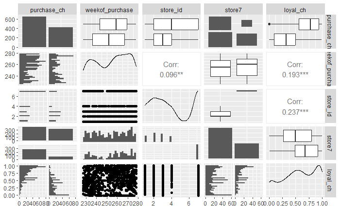

```r
ggpairs(oj_group1)
```

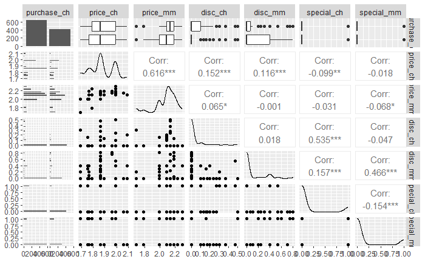

```r
ggpairs(oj_group2)
```

Group 1 - promising correlations store_id/ store to examine further, week of year and loyal customer Group 2 - discount prices for both MM and CH, possibly also with prce mm

Overall, the variables with the highest correlations to purchase_ch are disc_ch, disc_mm, loyal_ch, store and week of the year

```r
summary(oj_tidy)
```

```
 purchase_ch weekof_purchase    store_id       price_ch        price_mm        disc_ch           disc_mm
 t:653       Min.   :227.0   Min.   :1.00   Min.   :1.690   Min.   :1.690   Min.   :0.00000   Min.   :0.0000
 f:417       1st Qu.:240.0   1st Qu.:2.00   1st Qu.:1.790   1st Qu.:1.990   1st Qu.:0.00000   1st Qu.:0.0000
             Median :257.0   Median :3.00   Median :1.860   Median :2.090   Median :0.00000   Median :0.0000
             Mean   :254.4   Mean   :3.96   Mean   :1.867   Mean   :2.085   Mean   :0.05186   Mean   :0.1234
             3rd Qu.:268.0   3rd Qu.:7.00   3rd Qu.:1.990   3rd Qu.:2.180   3rd Qu.:0.00000   3rd Qu.:0.2300
             Max.   :278.0   Max.   :7.00   Max.   :2.090   Max.   :2.290   Max.   :0.50000   Max.   :0.8000
   special_ch       special_mm        loyal_ch        sale_price_mm   store7
 Min.   :0.0000   Min.   :0.0000   Min.   :0.000011   Min.   :1.190   f:714
 1st Qu.:0.0000   1st Qu.:0.0000   1st Qu.:0.325257   1st Qu.:1.690   t:356
 Median :0.0000   Median :0.0000   Median :0.600000   Median :2.090
 Mean   :0.1477   Mean   :0.1617   Mean   :0.565782   Mean   :1.962
 3rd Qu.:0.0000   3rd Qu.:0.0000   3rd Qu.:0.850873   3rd Qu.:2.130
 Max.   :1.0000   Max.   :1.0000   Max.   :0.999947   Max.   :2.290
```

```r
mod1a_disc_ch <- glm(purchase_ch ~ disc_ch,
                     data = oj_tidy,
                     family = binomial(link = "logit"))

mod1b_loyal_ch <- glm(purchase_ch ~ loyal_ch,
                     data = oj_tidy,
                     family = binomial(link = "logit"))

mod1c_store_id <- glm(purchase_ch ~ store_id,
                     data = oj_tidy,
                     family = binomial(link = "logit"))
```

```r
clean_names(tidy(mod1a_disc_ch))
```

| term | estimate | std_error | statistic | p_value |
| --- | --- | --- | --- | --- |
| (Intercept) | -0.2771144 | 0.06800249 | -4.075062 | 4.600204e-05 |
| disc_ch | -3.9819053 | 0.71481275 | -5.570557 | 2.539260e-08 |

```r
clean_names(tidy(mod1b_loyal_ch))
```

| term | estimate | std_error | statistic | p_value |
| --- | --- | --- | --- | --- |
| (Intercept) | 2.755397 | 0.1995901 | 13.80528 | 2.368569e-43 |
| loyal_ch | -6.094763 | 0.3611485 | -16.87606 | 6.750426e-64 |

```r
clean_names(tidy(mod1c_store_id))
```

| term | estimate | std_error | statistic | p_value |
| --- | --- | --- | --- | --- |
| (Intercept) | 0.4569870 | 0.12509853 | 3.653017 | 2.591772e-04 |
| store_id | -0.2379515 | 0.02942214 | -8.087500 | 6.090161e-16 |

Excellent! All these predictors are significant as the p-value is well below 0.05

| null_deviance | df_null | log_lik | aic | bic | deviance | df_residual | nobs |
| --- | --- | --- | --- | --- | --- | --- | --- |
| 1430.852 | 1069 | -695.452 | 1394.904 | 1404.855 | 1390.904 | 1068 | 1070 |

| null_deviance | df_null | log_lik | aic | bic | deviance | df_residual | nobs |
| --- | --- | --- | --- | --- | --- | --- | --- |
| 1430.852 | 1069 | -460.285 | 924.5701 | 934.5209 | 920.5701 | 1068 | 1070 |

| null_deviance | df_null | log_lik | aic | bic | deviance | df_residual | nobs |
| --- | --- | --- | --- | --- | --- | --- | --- |
| 1430.852 | 1069 | -680.1852 | 1364.37 | 1374.321 | 1360.37 | 1068 | 1070 |

Quite a difference in AIC and BIC for loyal_ch predictor, which is much lower than for the other two. This suggests that loyal_ch is a better predictor than the disc_ch and store_id. However, all are significant.

Let’s plot the AUC and compare the area under the curve for which is the best predictor

```r
oj_with_mod1a_disc_ch <- oj_tidy %>%
  add_predictions(mod1a_disc_ch, type = "response")

oj_with_mod1b_loyal_ch <- oj_tidy %>%
  add_predictions(mod1b_loyal_ch, type = "response")

oj_with_mod1c_store_id <- oj_tidy %>%
  add_predictions(mod1c_store_id, type = "response")
```

```r
roc_obj_mod1a <- oj_with_mod1a_disc_ch %>%
  roc(response = purchase_ch, predictor = disc_ch)

roc_obj_mod1b <- oj_with_mod1b_loyal_ch %>%
  roc(response = purchase_ch, predictor = loyal_ch)

roc_obj_mod1c <- oj_with_mod1c_store_id %>%
  roc(response = purchase_ch, predictor = store_id)
```

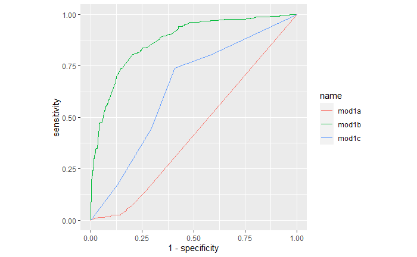

```r
roc_curve <- ggroc(
  data = list(
    mod1a = roc_obj_mod1a,
    mod1b = roc_obj_mod1b,
    mod1c = roc_obj_mod1c
  ),
  legacy.axes = TRUE
)+
  coord_fixed()

roc_curve
```

Great, this would support the AIC and BIC scores that the best predictor of whether customers buy CH orange juice is the loyalty to CH.

```r
auc(roc_obj_mod1a)
```

```
Area under the curve: 0.4316
```

```r
auc(roc_obj_mod1b)
```

```
Area under the curve: 0.874
```

```r
auc(roc_obj_mod1c)
```

```
Area under the curve: 0.6409
```

tHis is very clear too, the best predictor is loyalty to ch. The store_id predictor is also ok but not as good as loyalty The disc_ch has a AUC of < 0.5, which means it would perform worse than a random classifier!

## Cross validation for how representative our AUC above is

```r
train_control <- trainControl(method = "repeatedcv",
                              number = 5,
                              repeats = 100,
                              savePredictions = TRUE,
                              classProbs = TRUE,
                              summaryFunction = twoClassSummary)
```

```r
mod1a_disc_cv <- train(mod1a_disc_ch$formula,
                       data = oj_tidy,
                       trControl = train_control,
                       method = "glm",
                       family = binomial(link = "logit"))
```

```r
mod1b_loyal_ch_cv <- train(mod1b_loyal_ch$formula,
                       data = oj_tidy,
                       trControl = train_control,
                       method = "glm",
                       family = binomial(link = "logit"))
```

```r
mod1c_store_id_cv <- train(mod1c_store_id$formula,
                       data = oj_tidy,
                       trControl = train_control,
                       method = "glm",
                       family = binomial(link = "logit"))
```

```r
mod1a_disc_cv$results
```

|  | parameter | ROC | Sens | Spec | ROCSD | SensSD | SpecSD |
| --- | --- | --- | --- | --- | --- | --- | --- |
| 1 | none | 0.5683672 | 1 | 0 | 0.02357807 | 0 | 0 |

```r
mod1b_loyal_ch_cv$results
```

|  | parameter | ROC | Sens | Spec | ROCSD | SensSD | SpecSD |
| --- | --- | --- | --- | --- | --- | --- | --- |
| 1 | none | 0.8738876 | 0.8711556 | 0.7052126 | 0.02207841 | 0.0293378 | 0.04480991 |

```r
mod1c_store_id_cv$results
```

|  | parameter | ROC | Sens | Spec | ROCSD | SensSD | SpecSD |
| --- | --- | --- | --- | --- | --- | --- | --- |
| 1 | none | 0.6408474 | 0.828646 | 0.2331377 | 0.03338516 | 0.0900777 | 0.1121117 |

OK, these results are quite similar to the AUC values we had earlier. The loyal_ch is the best predictor again (ROC = 0.87), and store_id is ok too (ROC = 0.64). The disc_ch performs slightly better with cross validation than on all the data (not sure why?) but still not much better than getting the right answer half the time

## Model with all the classifiers to see how other predictors perform and if multiple might provide a better model.

```r
mod_all_pred <- glm(purchase_ch ~ .,
                    data = oj_tidy,
                    family = binomial(link = "logit"))

clean_names(tidy(mod_all_pred)) %>%
  arrange(p_value) %>%
  filter(p_value > 0.05)
```

| term | estimate | std_error | statistic | p_value |
| --- | --- | --- | --- | --- |
| (Intercept) | 2.852510393 | 1.78307267 | 1.59977238 | 0.1096491 |
| special_mm | 0.279984043 | 0.27276197 | 1.02647757 | 0.3046665 |
| store_id | -0.128415533 | 0.13718402 | -0.93608231 | 0.3492308 |
| weekof_purchase | -0.006520201 | 0.01065964 | -0.61167202 | 0.5407548 |
| special_ch | 0.110721695 | 0.32989219 | 0.33562994 | 0.7371499 |
| store7t | 0.017538989 | 0.70335541 | 0.02493617 | 0.9801059 |

```r
NA
NA
NA
```

ok, this is interesting. None of the above predictors are signficant, but they include store_id, which was significant when treated by itself!

| term | estimate | std_error | statistic | p_value |
| --- | --- | --- | --- | --- |
| loyal_ch | -6.251881 | 0.3956246 | -15.802560 | 2.987326e-56 |
| disc_mm | 2.314059 | 0.5333661 | 4.338594 | 1.433970e-05 |
| price_mm | -3.125925 | 0.8597691 | -3.635773 | 2.771488e-04 |
| disc_ch | -3.507483 | 1.1067209 | -3.169257 | 1.528290e-03 |
| price_ch | 4.490060 | 1.7715902 | 2.534480 | 1.126143e-02 |

Let’s make a model with just these significant predictors

| term | estimate | std_error | statistic | p_value |
| --- | --- | --- | --- | --- |
| (Intercept) | 2.521811 | 1.5667994 | 1.609530 | 1.075005e-01 |
| loyal_ch | -6.382168 | 0.3894567 | -16.387360 | 2.354495e-60 |
| disc_mm | 2.399670 | 0.4137385 | 5.799967 | 6.632800e-09 |
| price_mm | -3.562292 | 0.8004293 | -4.450477 | 8.567976e-06 |
| disc_ch | -4.282714 | 0.9010880 | -4.752825 | 2.005936e-06 |
| price_ch | 4.096246 | 1.1341553 | 3.611715 | 3.041787e-04 |

[figure not shown]

```r
auc(roc_obj_mod_5pred)
```

```
Area under the curve: 0.8999
```

The AUC obtained from cross validation using just the loyal_ch as classifer was only slightly less than this model (ROC with loyal_ch = 0.8738876) suggesting that the main predictor is the loyal_ch. As they are so close, it would also suggest that there isn’t any strong evidence of overfitting.